# Predicting Science Scores

```r
library(readxl)
library(dplyr)
library(texreg)
student_data <- read_excel("hsb2.xlsx")

race_labels <- c("hispanic", "asian", "african-american", "white")
prog_labels <- c("general","academic","vocational")

student_data <-  mutate(student_data, gender = factor(female, labels=c("M","F")))
student_data <-  mutate(student_data, social_economic_group = factor(ses,
                                                              labels=c("L","M","H")))
student_data <-  mutate(student_data, race = factor(race, labels=race_labels))
student_data <-  mutate(student_data, program = factor(prog, labels=prog_labels))
student_data <-  mutate(student_data, school_type = factor(schtyp,
                                                           labels=c("public","private")))

student_data <-  select(student_data, -female, -prog, -ses, -schtyp)

head(student_data)
```

| id | race | read | write | math | science | socst | gender | social_economic_group | program | school_type |
| --- | --- | --- | --- | --- | --- | --- | --- | --- | --- | --- |
| 70 | white | 57 | 52 | 41 | 47 | 57 | M | L | general | public |
| 121 | white | 68 | 59 | 53 | 63 | 61 | F | M | vocational | public |
| 86 | white | 44 | 33 | 54 | 58 | 31 | M | H | general | public |
| 141 | white | 63 | 44 | 47 | 53 | 56 | M | H | vocational | public |
| 172 | white | 47 | 52 | 57 | 53 | 61 | M | M | academic | public |
| 113 | white | 44 | 52 | 51 | 63 | 61 | M | M | academic | public |

```r
# for comparison I am going to build both models
model1 <- lm(science ~ math+gender,data=student_data)
model2 <- lm(science ~ math*gender,data=student_data)
screenreg(list(model1,model2),digits=4)
```

```
##
## ========================================
##               Model 1       Model 2
## ----------------------------------------
## (Intercept)    18.1051 ***   17.1997 ***
##                (3.1827)      (4.5194)
## math            0.6641 ***    0.6812 ***
##                (0.0582)      (0.0840)
## genderF        -2.2009 *     -0.4627
##                (1.0914)      (6.2424)
## math:genderF                 -0.0330
##                              (0.1167)
## ----------------------------------------
## R^2             0.4083        0.4085
## Adj. R^2        0.4023        0.3994
## Num. obs.     200           200
## RMSE            7.6826        7.7006
## ========================================
## *** p < 0.001, ** p < 0.01, * p < 0.05
```

The two prediction formulas for science score are:

```
# model 1
science = 18.1 + 0.664*math -2.20*genderF

# model 2
science = 17.2 + 0.681*math -0.463*genderF -0.0330*math*genderF
```

This means for male students (genderF=0) we predict:

```
# model 1
science = 18.1 + 0.664*math

# model 2
science = 17.2 + 0.681*math
```

and for female students we predict

```
# model 1
science = 18.1 + 0.664*math -2.20
        = 15.9 + 0.664*math

# model 2
science = 17.2 + 0.681*math -0.463 -0.0330*math
        = 16.7 + 0.648*math
```

Model 1 assumes the relationship between science and math is independent of gender. For each 1 mark increase in math our predicted science grade increases by 0.664 marks.

Model 2 allows an the science~maths relationship to be dependent on gender (there is an interaction between the effect of math and gender on science score). For each 1 mark increase in math our predicted science grade increases by 0.681 marks for males, and 0.648 for females.

Let`s look at the p-value of the interaction term (we can see the full information in the summary):

```r
summary(model2)
```

```
##
## Call:
## lm(formula = science ~ math * gender, data = student_data)
##
## Residuals:
##      Min       1Q   Median       3Q      Max
## -21.1707  -4.4971   0.1519   4.4433  24.9597
##
## Coefficients:
##              Estimate Std. Error t value Pr(>|t|)
## (Intercept)  17.19972    4.51935   3.806 0.000189 ***
## math          0.68116    0.08399   8.110  5.4e-14 ***
## genderF      -0.46270    6.24243  -0.074 0.940989
## math:genderF -0.03300    0.11666  -0.283 0.777610
## ---
## Signif. codes:  0 '***' 0.001 '**' 0.01 '*' 0.05 '.' 0.1 ' ' 1
##
## Residual standard error: 7.701 on 196 degrees of freedom
## Multiple R-squared:  0.4085, Adjusted R-squared:  0.3994
## F-statistic: 45.12 on 3 and 196 DF,  p-value: < 2.2e-16
```

The p-value shows the calculated probability that under the null hypothesis the value of the math:genderF coefficient is 0 that we could see (due to the random sample of students selected) a coefficient of size -0.03. In this case the p-val is 0.78 or 78% so we cannot reject this null hypothesis.

We can also perform this test way to check this is to compare to the model without the interaction term using an anova test, to see if the decrease in variance in the residuals could also be by chance under the null hypothesis that there is no interaction.

```r
anova(model1,model2)
```

|  | Res.Df | RSS | Df | Sum of Sq | F | Pr(>F) |
| --- | --- | --- | --- | --- | --- | --- |
| 1 | 197 | 11627.34 | NA | NA | NA | NA |
| 2 | 196 | 11622.60 | 1 | 4.743288 | 0.0799894 | 0.7776102 |

In this case the test shows the same result: that 78% of the time we might see the slight improvement in performance (smaller residuals) under the null hypothesis that there is no interaction. Therefore our analysis cannot provide evidence that the relationship between science and math scores is different for females and males.

Finally lets plot these relationships. We will create a two panel plot showing the two models, and add trendlines for males and females. To do this we will use the formulas calculated above, and the abline function which can also accept an intercept `a` and slope `b` arguments:

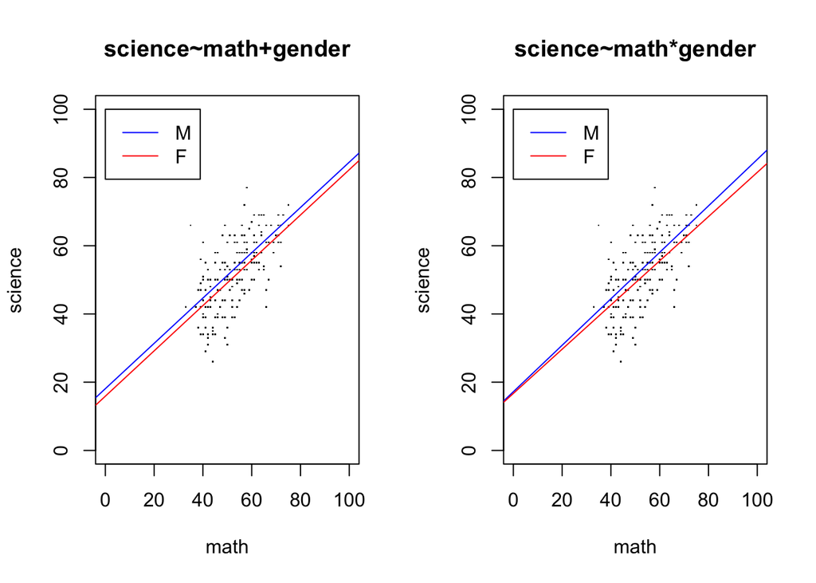

```r
par(mfrow=c(1,2))
plot(science~math, data=student_data,
     xlim=c(0,100),ylim=c(0,100),pch='.',
     main="science~math+gender")
abline(a=18.1, b=0.664, col='blue')
abline(a=15.9, b=0.664, col='red')
legend(0,100,legend=c('M','F'),col=c('blue','red'), lty= 1)

plot(science~math, data=student_data,xlim=c(0,100),ylim=c(0,100),pch='.',
     main="science~math*gender")
abline(a=17.2, b=0.681, col='blue')
abline(a=16.7, b=0.648, col='red')
legend(0,100,legend=c('M','F'),col=c('blue','red'), lty= 1)
```

We see that for the data region the two fitted lines are very close:

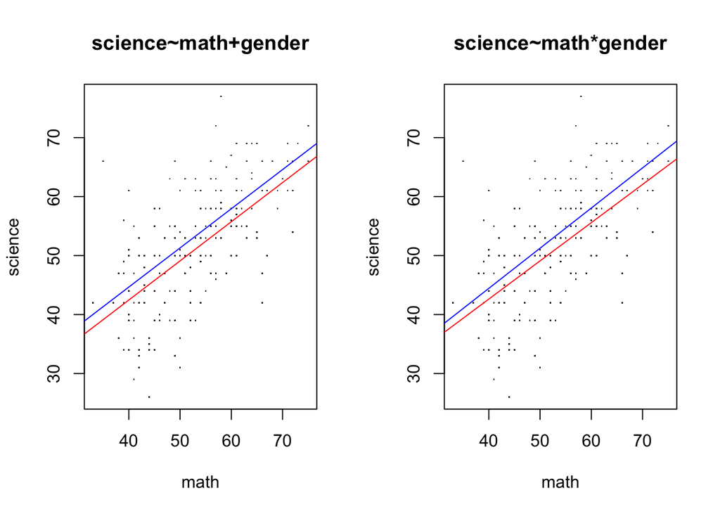

```r
par(mfrow=c(1,2))
plot(science~math, data=student_data, pch='.', main="science~math+gender")
abline(a=18.1, b=0.664, col='blue')
abline(a=15.9, b=0.664, col='red')
legend(0,100,legend=c('M','F'),col=c('blue','red'), lty= 1)

plot(science~math, data=student_data,pch='.',main="science~math*gender")
abline(a=17.2, b=0.681, col='blue')
abline(a=16.7, b=0.648, col='red')
legend(0,100,legend=c('M','F'),col=c('blue','red'), lty= 1)
```

### Using polynomials

```r
# for comparison I am going to build both models
polymodel1 <- lm(science ~ poly(math,1),data=student_data)
polymodel2 <- lm(science ~ poly(math,2),data=student_data)
polymodel3 <- lm(science ~ poly(math,3),data=student_data)
polymodel4 <- lm(science ~ poly(math,4),data=student_data)

screenreg(list(polymodel1,polymodel2,polymodel3,polymodel4),digits=4)
```

```
##
## ======================================================================
##                 Model 1       Model 2       Model 3       Model 4
## ----------------------------------------------------------------------
## (Intercept)      51.8650 ***   51.8650 ***   51.8650 ***   51.8650 ***
##                  (0.5474)      (0.5488)      (0.5444)      (0.5369)
## poly(math, 1)    88.2156 ***
##                  (7.7418)
## poly(math, 2)1                 88.2156 ***
##                                (7.7615)
## poly(math, 2)2                  0.1566
##                                (7.7615)
## poly(math, 3)1                               88.2156 ***
##                                              (7.6988)
## poly(math, 3)2                                0.1566
##                                              (7.6988)
## poly(math, 3)3                              -15.8115 *
##                                              (7.6988)
## poly(math, 4)1                                             88.2156 ***
##                                                            (7.5925)
## poly(math, 4)2                                              0.1566
##                                                            (7.5925)
## poly(math, 4)3                                            -15.8115 *
##                                                            (7.5925)
## poly(math, 4)4                                             19.4018 *
##                                                            (7.5925)
## ----------------------------------------------------------------------
## R^2               0.3960        0.3960        0.4088        0.4279
## Adj. R^2          0.3930        0.3899        0.3997        0.4162
## Num. obs.       200           200           200           200
## RMSE              7.7418        7.7615        7.6988        7.5925
## ======================================================================
## *** p < 0.001, ** p < 0.01, * p < 0.05
```

As an example let plot the 3rd order polynomial fit (`poly3`):

```r
# construct a dataframe containing input math scores
# we will use to predict science score
math_seq <- seq(from=0, to=100, by=1)
student_data_for_fit <- data.frame(math=math_seq)
head(student_data_for_fit)
```

|  | math |
| --- | --- |
| 1 | 0 |
| 2 | 1 |
| 3 | 2 |
| 4 | 3 |
| 5 | 4 |
| 6 | 5 |

```r
fit_poly3 <- predict(polymodel3, newdata = student_data_for_fit )
# we can store these into our student_data_for_fit dataframe
student_data_for_fit$fit_poly3 <- fit_poly3
head(student_data_for_fit)
```

|  | math | fit_poly3 |
| --- | --- | --- |
| 1 | 0 | 183.4476 |
| 2 | 1 | 174.7255 |
| 3 | 2 | 166.3544 |
| 4 | 3 | 158.3277 |
| 5 | 4 | 150.6390 |
| 6 | 5 | 143.2815 |

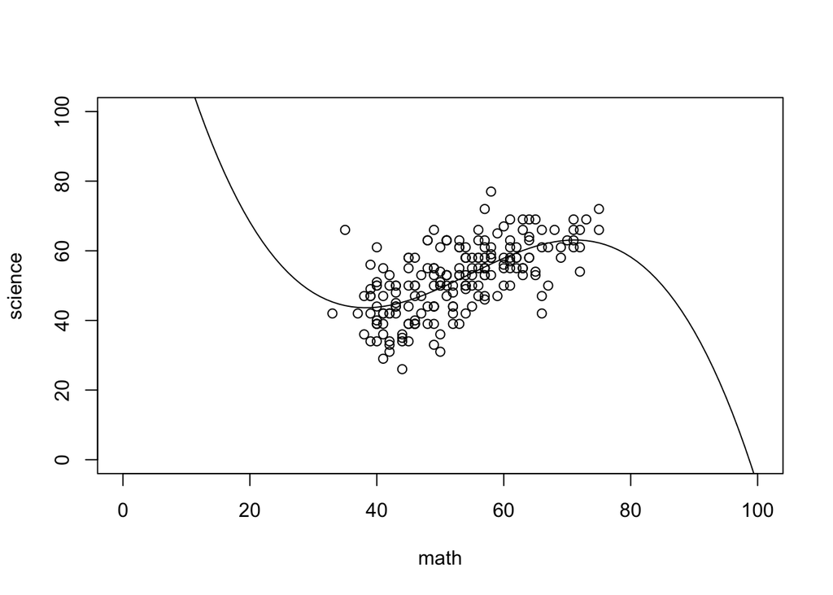

```r
plot(science~math, data=student_data, xlim=c(0,100), ylim=c(0,100))
lines(student_data_for_fit$math, student_data_for_fit$fit_poly3)
```

Note that in the region of the data our predictions are sensible (increased math score means increased science score) but outside this region the cubic polynomial predicts decreasing science score with increasing math score. This shows that we need to choose an appropriate fit function shape, and take care when using our model to make predictions that our outside of the data range used to build the model.

Let’s look at all models:

```r
fit_poly1 <- predict(polymodel1, newdata = student_data_for_fit )
fit_poly2 <- predict(polymodel2, newdata = student_data_for_fit )
fit_poly4 <- predict(polymodel4, newdata = student_data_for_fit )

student_data_for_fit$fit_poly1 <- fit_poly1
student_data_for_fit$fit_poly2 <- fit_poly2
student_data_for_fit$fit_poly4 <- fit_poly4

head(student_data_for_fit)
```

|  | math | fit_poly3 | fit_poly1 | fit_poly2 | fit_poly4 |
| --- | --- | --- | --- | --- | --- |
| 1 | 0 | 183.4476 | 16.72447 | 17.04387 | 1094.1834 |
| 2 | 1 | 174.7255 | 17.39197 | 17.69927 | 1016.7636 |
| 3 | 2 | 166.3544 | 18.05947 | 18.35490 | 943.5858 |
| 4 | 3 | 158.3277 | 18.72697 | 19.01076 | 874.4963 |
| 5 | 4 | 150.6390 | 19.39447 | 19.66684 | 809.3445 |
| 6 | 5 | 143.2815 | 20.06197 | 20.32315 | 747.9822 |

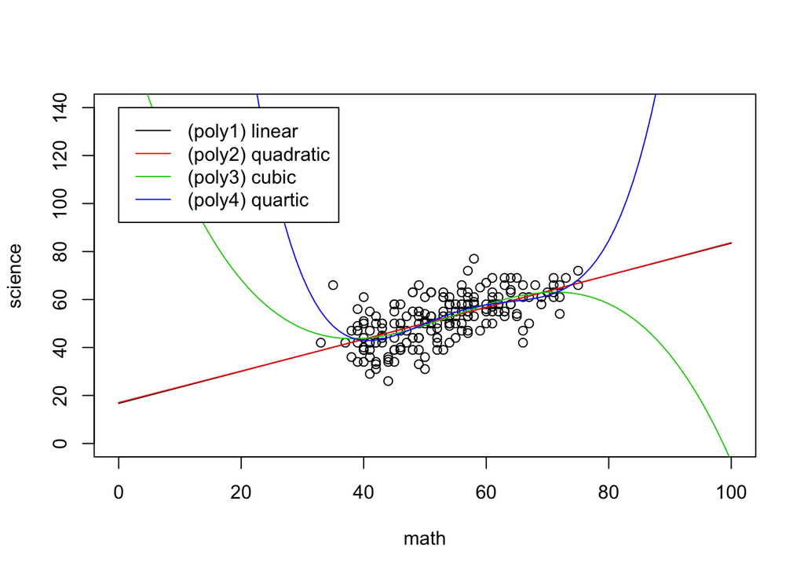

```r
plot(science~math, data=student_data, xlim=c(0,100), ylim=c(0,140))
lines(student_data_for_fit$math, student_data_for_fit$fit_poly1, col=1)
lines(student_data_for_fit$math, student_data_for_fit$fit_poly2, col=2)
lines(student_data_for_fit$math, student_data_for_fit$fit_poly3, col=3)
lines(student_data_for_fit$math, student_data_for_fit$fit_poly4, col=4)
leg_labels = c("(poly1) linear",
               "(poly2) quadratic",
               "(poly3) cubic",
               "(poly4) quartic")
legend(x=0,y=140, legend=leg_labels, col=1:4, lty=1)
```

Its interesting to see that the quadratic fit (poly2) is very similar to the linear fit (poly1). The `poly` function uses orthogonal polynomials for fitting. This means the coefficients returned do not correspond to the standard form for a polynomial:

```
y = b0 + b1*x + b2*x^2 + b3*x^3 + b4*x^4...
```

However we can specify the formula in such a way that the fit returned uses these values. For example for a quadratic fit we add an interaction term `I()` for `math^2`:

```r
quadratic_model <- lm(science ~ math +I(math^2),data=student_data)
summary(quadratic_model)
```

```
##
## Call:
## lm(formula = science ~ math + I(math^2), data = student_data)
##
## Residuals:
##      Min       1Q   Median       3Q      Max
## -20.0956  -4.7682  -0.0912   4.8682  25.8824
##
## Coefficients:
##              Estimate Std. Error t value Pr(>|t|)
## (Intercept) 1.704e+01  1.614e+01   1.056    0.292
## math        6.553e-01  6.081e-01   1.078    0.283
## I(math^2)   1.131e-04  5.607e-03   0.020    0.984
##
## Residual standard error: 7.761 on 197 degrees of freedom
## Multiple R-squared:  0.396,  Adjusted R-squared:  0.3899
## F-statistic: 64.59 on 2 and 197 DF,  p-value: < 2.2e-16
```

The coefficients here correspond to the standard polynomial form: `a + b*x + c*x^2` i.e.

[output not shown]

The small coefficient found for the quadratic term is the reason the fit is similar to the linear fit:

```r
linear_model <- lm(science ~ math,data=student_data)
summary(linear_model)
```

```
##
## Call:
## lm(formula = science ~ math, data = student_data)
##
## Residuals:
##      Min       1Q   Median       3Q      Max
## -20.0945  -4.7688  -0.0995   4.8880  25.9130
##
## Coefficients:
##             Estimate Std. Error t value Pr(>|t|)
## (Intercept) 16.72447    3.13216    5.34 2.54e-07 ***
## math         0.66750    0.05858   11.39  < 2e-16 ***
## ---
## Signif. codes:  0 '***' 0.001 '**' 0.01 '*' 0.05 '.' 0.1 ' ' 1
##
## Residual standard error: 7.742 on 198 degrees of freedom
## Multiple R-squared:  0.396,  Adjusted R-squared:  0.393
## F-statistic: 129.8 on 1 and 198 DF,  p-value: < 2.2e-16
```

```
science = 16.7 + 0.67*math
```

Let’s compare all models using the anova test. This can compare a sequence of nested models:

```r
anova(polymodel1,polymodel2,polymodel3,polymodel4)
```

|  | Res.Df | RSS | Df | Sum of Sq | F | Pr(>F) |
| --- | --- | --- | --- | --- | --- | --- |
| 1 | 198 | 11867.37 | NA | NA | NA | NA |
| 2 | 197 | 11867.34 | 1 | 0.02451227 | 0.0004252231 | 0.98356912 |
| 3 | 196 | 11617.34 | 1 | 250.00293590 | 4.3368899599 | 0.03859962 |
| 4 | 195 | 11240.91 | 1 | 376.43162043 | 6.5300933740 | 0.01136884 |

Here the reduction seen in the size of the residuals is:

[output not shown]

Let’s see about making a 5th order polynomial fit:

```r
polymodel5 <- lm(science ~ poly(math,5),data=student_data)
polymodel6 <- lm(science ~ poly(math,6),data=student_data)

anova(polymodel1,polymodel2,polymodel3,polymodel4,polymodel5,polymodel6)
```

|  | Res.Df | RSS | Df | Sum of Sq | F | Pr(>F) |
| --- | --- | --- | --- | --- | --- | --- |
| 1 | 198 | 11867.37 | NA | NA | NA | NA |
| 2 | 197 | 11867.34 | 1 | 0.02451227 | 0.0004244912 | 0.98358348 |
| 3 | 196 | 11617.34 | 1 | 250.00293590 | 4.3294251953 | 0.03877900 |
| 4 | 195 | 11240.91 | 1 | 376.43162043 | 6.5188536123 | 0.01144656 |
| 5 | 194 | 11181.13 | 1 | 59.77598999 | 1.0351705520 | 0.31022106 |
| 6 | 193 | 11144.80 | 1 | 36.33264710 | 0.6291905220 | 0.42862645 |

Here the reduction seen in the size of the residuals is:

[output not shown]

Therefore from the anova test result alone we see no evidence for using a 5th order polynomial to fit the math score, and would suggest our model uses a 4th order polynomial.

However given the issues we see with using the 3rd and 4th order polynomials to predict scores outside the range of math scores used to build the model, and the fact that the improvement in variance was not significant at a 0.01 or 1% level, we would probably say that the linear model is most appropriate in this case to describe the relationship.